# Kvinnor och män i Dalarna

# 4 Jämställd hälsa

Jämställd hälsa är det femte delmålet. Kvinnor och män, flickor och pojkar ska ha samma förutsättningar för en god hälsa och erbjudas vård och omsorg på lika villkor. Idag finns det stora skillnader i hälsa och ohälsa mellan kvinnor och män. Flickor och kvinnor är sjukskrivna för symptom som är kopplade till psykisk ohälsa i betydligt högre utsträckning än män, samtidigt dör fler män än kvinnor av självmord, i arbetsplatsolyckor, i hjärt- och kärlsjukdomar och av cancer. Förklaringar kan bland annat kopplas till brister i arbetsmiljön, att inte söka vård i tid och skillnader i vårdens bemötande.

## 4.1 Ohälsotalet

Ohälsotalet[^16] mäter i vilken utsträckning personer är borta från arbetet på grund av nedsatt arbetsförmåga, mätt under ett års tid. Ohälsotalet varierar över tid och var relativt högt under början av 2000-talet. Därefter syns en klart nedåtgående trend. Under hela tidsperioden har ohälsotalet varit högre för kvinnor än för män även om skillnaden mellan könen har minskat något över tid.

Ohälsotalet för Dalarnas befolkning visar att det finns skillnader mellan länets kommuner. För män är ohälsotalet år 2023 högst i Hedemora och lägst i Falun. För kvinnor är ohälsotalet högst i Rättvik och lägst i Leksand. För att fastställa orsaken till skillnaderna mellan kommuner behövs djupare studier och analyser, men potentiella faktorer kan vara att branschstrukturen skiljer sig mellan kommunerna och att det är olika hög sjukfrånvaro i olika branscher, men även att socioekonomiska förutsättningar skiljer sig åt mellan kommunerna i Dalarna.

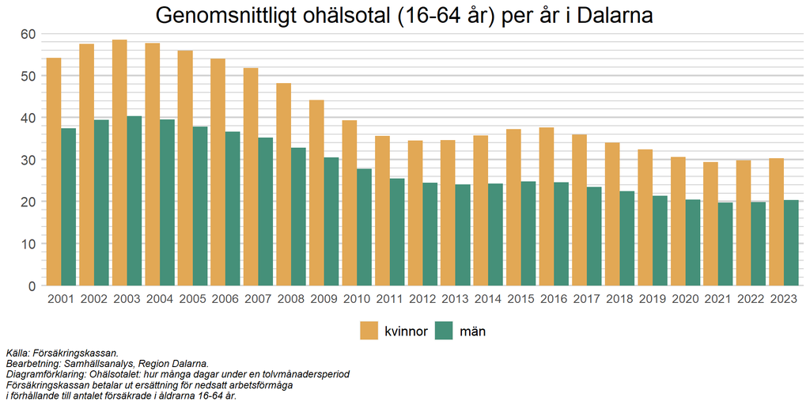

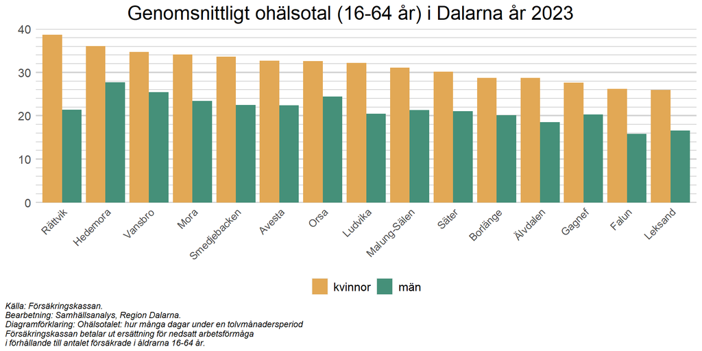

## 4.2 Sjukpenningtalet

I likhet med ohälsotalet tenderar sjukpenningtalet, som enbart innefattar sjukpenning och rehabiliteringspenning, att variera kraftigt över tiden. I början av 2000-talet var talet högt för både kvinnor och män, för att därefter minska rejält fram till 2010. Därefter har sjukpenningtalet både gått upp och ned, men på senare år kan en ökning återigen skönjas. Kvinnor är sjukskrivna i större utsträckning än män, vilket återspeglas i sjukpenningtalet. Att talet förändras över tid behöver inte nödvändigtvis bero på att människor blir mer eller mindre sjuka. Det kan snarare bero på en mer eller mindre restriktiv syn på vad som krävs för att bli sjukskriven, något som ofta är politiskt styrt. Exempelvis beror den kraftiga nedgången i sjukpenningtalet mellan 2002 och 2010 sannolikt inte på att arbetstagare var mindre sjuka, utan på att bedömningen av vad som berättigar en sjukskrivning var hårdare.

Även när det kommer till sjukpenningtalet finns det skillnader mellan Dalarnas kommuner. För män är talet högst i Orsa, medan det för kvinnor är högst i Rättvik. Sjukpenningtalet är en delmängd av ohälsotalet och därför samvarierar resultaten mellan kommunerna i stort. Talet är lägst för både kvinnor och män i Falun

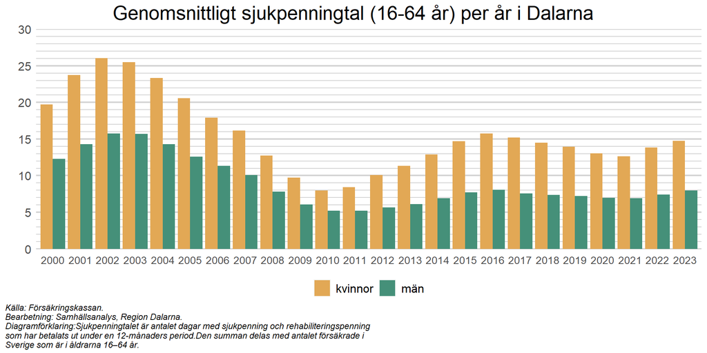

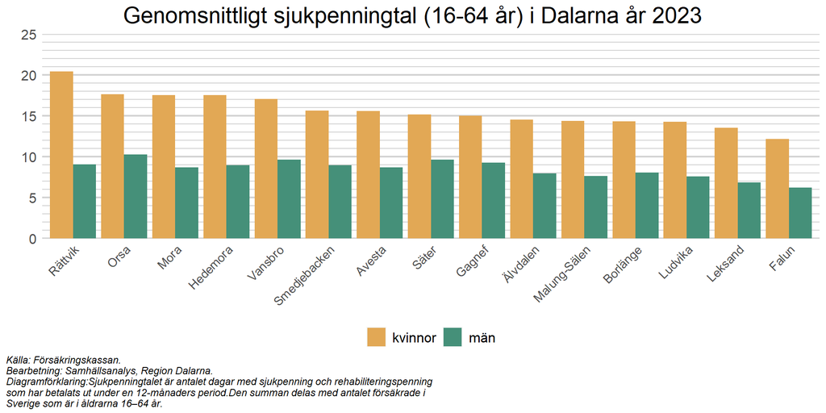

## 4.3 Stress

Trots minskningen i antalet totala frånvarodagar (ohälsotalet och sjukpenningtalet) har antalet sjukfall kopplade till stressrelaterade symptom ökat dramatiskt sedan 2010. Även för dessa sjukfall ses en trend där antalet minskade markant under perioden 2007-2010, för att sedan öka. Kvinnor står för cirka 80 procent av dessa sjukskrivningar. Trots den stora skillnaden i antal mellan kvinnor och män, så är ökningen relativt likvärdig. Antalet pågående sjukfall kopplade till stress mellan 2010 och 2016 har ungefär sexfaldigats för respektive grupp och från 2016 till idag har utvecklingen stabiliserats något, men ligger kvar på en mycket högre nivå än innan 2010. Att utröna vad det ökade antalet sjukfall beror på är svårt, men det finns ett väl belagt samband mellan psykiatriska diagnoser (såsom svår stress) och den psykosociala arbetsmiljön.[^17]

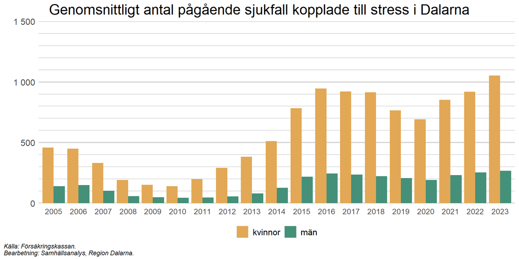

## 4.4 Skillnader i sjukfall mellan branscher

Generellt är det stora skillnader i antalet startade sjukfall (per 1 000 förvärvsarbetande) mellan olika branscher. För kvinnor är antalet störst i ett typiskt kvinnodominerat yrke som vård och omsorg, vilket kan vara en förklaring till att kvinnor är sjukskrivna i större utsträckning än män. För män är det istället inom transportbranschen, en mansdominerad bransch, som antalet startade sjukfall är högst. Oavsett kön, är antal startade sjukfall lägst inom klassiska kontorsjobb som ekonomi, juridik och IT. Notera även att antalet startade sjukfall (per 1 000 förvärvsarbetande) är högre för kvinnor än för män i samtliga branscher i diagrammet nedan.

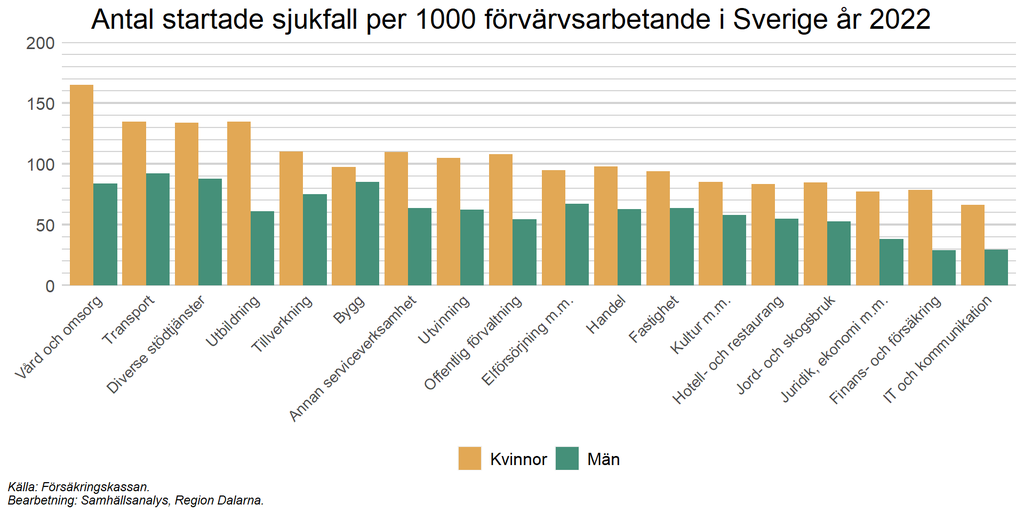

# 5 Makt och politik

Det första av de jämställdhetspolitiska delmålen lyder “en jämn fördelning av makt och inflytande”. Detta mäts bland annat genom kvinnors och mäns representation på maktpositioner i både politik och näringsliv. Historiskt har, av förklarliga skäl, män befolkat dessa positioner och kvinnor i undantagsfall, men dessvärre visar nuläget också att många traditionella mönster består. Ju högre upp i hierarkin, desto fler män på positionerna. Jämställdhetsmyndigheten skriver att:

> Näringsliv, högre utbildningar och organisationer med mindre insyn har få kvinnor på höga positioner.[^18]

Samtidigt har bilden förbättrats inom offentlig sektor och inom politiken generellt de senaste decennierna.

## 5.1 Politiskt valda

Den politiska sfären har historiskt varit mansdominerad och kvinnor har haft avsevärt färre tunga politiska uppdrag. Det första diagrammet i det här avsnittet visar könsfördelningen bland riksdagsledamöter från valet 1973 till 2022. Riksdagens könsfördelning har under den här tidsperioden sett en stor förändring och utveckling. Vid riksdagsvalet 1973 var en övervägande majoritet av de folkvalda ledamöterna män. Endast drygt 70 kvinnor återfanns på bänkarna i Riksdagen under den här mandatperioden. 49 år senare är männen fortfarande fler än kvinnorna, men skillnaden mellan könen är bara 27 stycken ledamöter. Den mest jämställda Riksdagen i Sverige var mandatperioden som tog sin början 2006 då antalet kvinnor var 165.

Trenden på nationell nivå syns även på regional nivå där trenden går mot en mer jämställd representation bland de folkvalda. Vid landstingsvalet 1982 i Dalarna var antalet manliga ledamöter i regionfullmäktige övervägande män, medan könsfördelningen vid regionvalet 2014 var i princip helt jämställd med ett nästan jämnt antal män och kvinnor bland folkvalda i regionens fullmäktige. Efter valet 2018 syns däremot återigen en ökning av andelen män i regionfullmäktige och sedan det senaste valet (2022) sitter 11 fler män än kvinnor i regionfullmäktige.

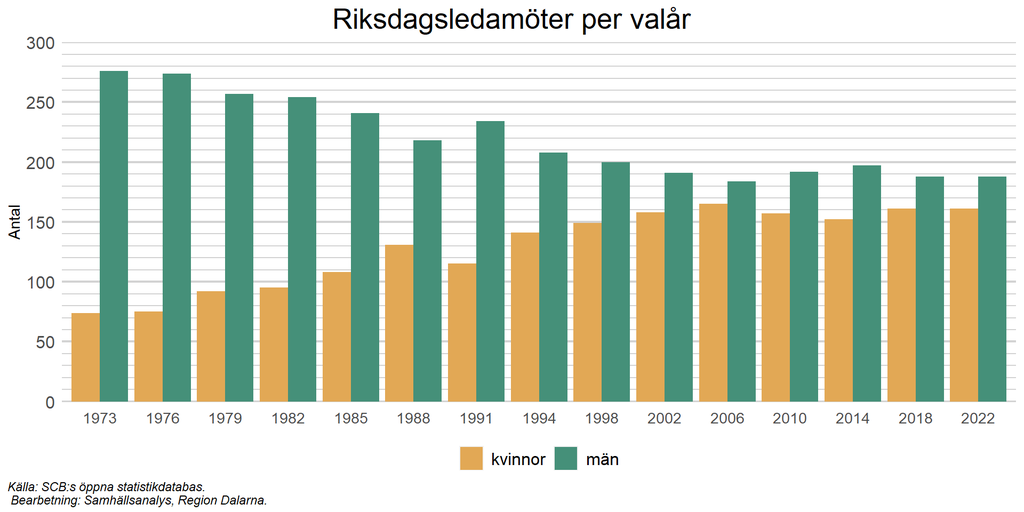

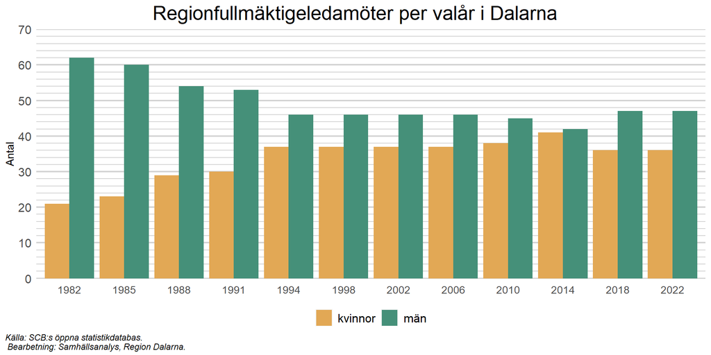

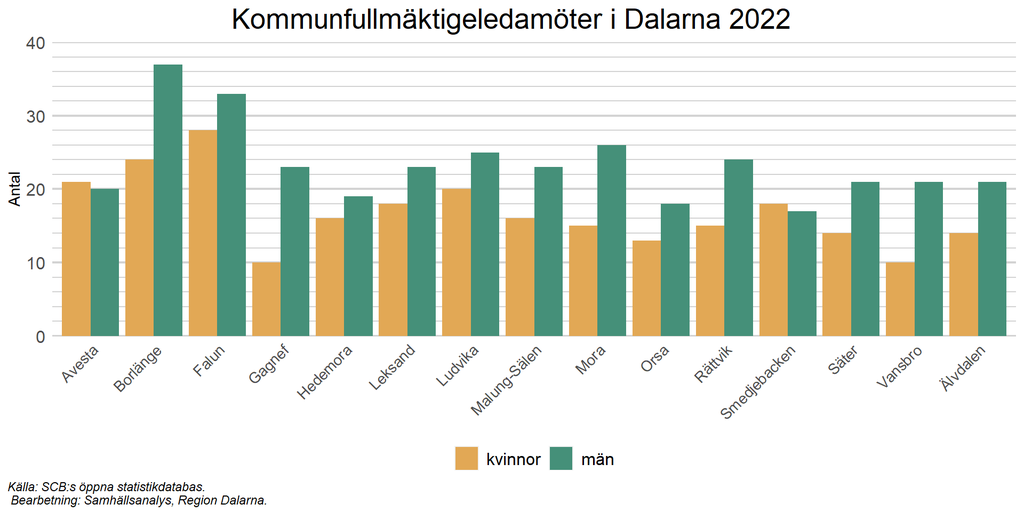

## 5.2 Chefsskap

Ett annat mått på makt är den ställning individen har på arbetsplatsen och i yrkeslivet. I det först diagrammet nedan visas andelen chefer uppdelade efter kön och för olika utbildningsnivåer. I samtliga grupper i Dalarna är en större andel av männen sysselsatta i någon form av chefsposition jämfört med motsvarande grupp kvinnor. Andelen chefer är även tydligt kopplad till utbildningsnivå där högre utbildning är associerad med en högre andel individer i chefspositioner. Bland gruppen sysselsatta män i Dalarna med eftergymnasial utbildning innehar drygt 11 procent någon form av chefsställning. Bland kvinnor med eftergymnasial utbildning är motsvarande siffra ungefär 8 procent.

I det andra diagrammet ser vi utveckling över tid. Andelen kvinnor i chefsposition i Dalarna har nästintill fördubblats under en tjugoårsperiod, och under samma period är andelen män i chefspositioner mer eller mindre oförändrat. Det betyder att antalet chefspositioner har ökat i antal, men totalt sett så går utvecklingen över tid ändå i en mer jämställd riktning, även om situationen på arbetsmarknaden fortsatt får anses vara ojämställd.

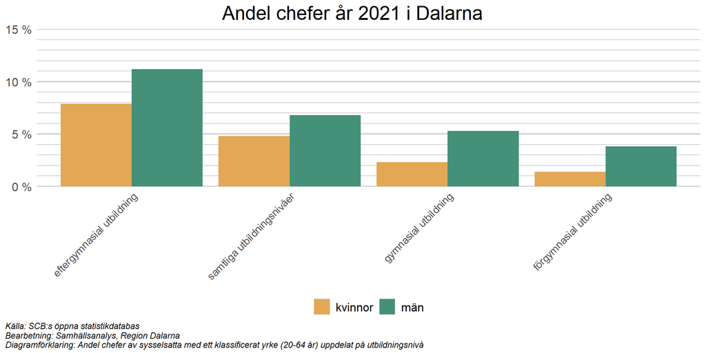

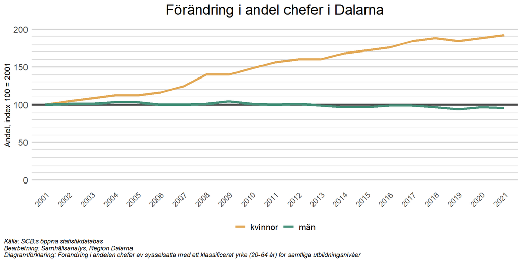

[^1]: Statistiska Centralbyrån, På tal om kvinnor och män, https://www.scb.se/hitta-statistik/statistik-efter-amne/levnadsforhallanden/jamstalldhet/jamstalldhetsstatistik/pong/publikationer/pa-tal-om-kvinnor-och-man---lathund-om-jamstalldhet-2022/
[^2]: Statistiska Centralbyrån, En fråga om tid - en studie av tidsanvändningen bland kvinnor och män 2021. https://www.scb.se/contentassets/4e98132b0b784a01b6e4762e909a6fa2/le0103_2021a01_br_lebr2202.pdf
[^3]: Regeringen, Budgetproposition 2022/23:1 bilaga 3, Ekonomisk jämställdhet:https://www.regeringen.se/contentassets/46945970585240a4a5bfd9a0f75ecf3d/ekonomisk-jamstalldhet.pdf
[^4]: Jämställdhetsmyndigheten Regionalpolitik, könsmönster och jämställdhetsambitioner (2022:16 bilaga 1) Bilaga till rapporten Bättre styrning för bättre resultat <https://jamstalldhetsmyndigheten.se/media/xkfccjgj/rapport-2022-16-bilaga-1-regionalpolitik-ko-nsmo-nster-och-ja-msta-lldhetsambitioner.pdf
[^5]: Region Dalarna, Kvinnor och män i Dalarna ur ett jämställdhetsperspektiv: <https://www.regiondalarna.se/contentassets/78c014a2f54a405a9467906f995f29d4/jamstalldhetsrapport.pdf
[^6]: SCB, https://www.scb.se/hitta-statistik/statistik-efter-amne/befolkning/befolkningsframskrivningar/demografisk-analys/pong/statistiknyhet/demografisk-analys-livslangdstabeller-efter-utbildningsniva
[^7]: Expertgruppen för studier i offentlig ekonomi (2021) https://eso.expertgrupp.se/wp-content/uploads/2020/03/ESO-2021_7_forsorjning-med-fordrojning_webb.pdf
[^8]: Jämställdhetsmyndigheten (2022) https://jamstalldhetsmyndigheten.se/media/s5wdbimq/rapport-sta-rkta-mo-jligheter-genom-samverkan.pdf
[^9]: Expertgruppen för studier i offentlig ekonomi (2021), https://eso.expertgrupp.se/wp-content/uploads/2020/03/ESO-2021_7_forsorjning-med-fordrojning_webb.pdf
[^10]: Etablering för fler – jämställda möjligheter till integration (SOU 2023:24) https://www.regeringen.se/contentassets/aaae962745b74fa4abc01f7926bb5adc/sou-2023_24_pdf-a_webb.pdf
[^11]: Regeringen (2022) Prop. 2022/23:1 Bilaga 3 Ekonomisk jämställdhet 2022 https://www.regeringen.se/contentassets/46945970585240a4a5bfd9a0f75ecf3d/ekonomisk-jamstalldhet.pdf
[^12]: SCB: https://www.scb.se/hitta-statistik/statistik-efter-amne/arbetsmarknad/loner-och-arbetskostnader/lonestrukturstatistik-hela-ekonomin/pong/tabell-och-diagram/kvinnors-lon-i-procent-av-mans-lon-efter-sektor
[^13]: Kronofogden: https://kronofogden.se/om-kronofogden/statistik/statistik-om-antal-skuldsatta
[^14]: Jämställdhetsmyndighetens hemsida, https://jamstalldhetsmyndigheten.se/jamstalldhet-i-sverige/delmal-4-jamn-fordelning-av-det-obetalda-hem-och-omsorgsarbetet/
[^15]: Regeringen, Budgetproposition 2022/23:1 bilaga 3, Ekonomisk jämställdhet:https://www.regeringen.se/contentassets/46945970585240a4a5bfd9a0f75ecf3d/ekonomisk-jamstalldhet.pdf
[^16]: Ohälsotalet: hur många dagar under en tolvmånadersperiod Försäkringskassan betalar ut ersättning för nedsatt arbetsförmåga i förhållande till antalet försäkrade i åldersgruppen 16-64 år
[^17]: Försäkringskassan, Korta analyser 2016:2, ‘’Sjukskrivning för reaktioner på svår stress ökar mest.’’: https://www.forsakringskassan.se/download/18.3a5418591814e228e4413b2/1661267958656/psykisk-ohalsa-korta-analyser-2016-2.pdf
[^18]: Jämställdmyndighetens webbsida: https://jamstalldhetsmyndigheten.se/jamstalldhet-i-sverige/delmal-1-jamn-fordelning-av-makt-och-inflytande/